# Post-test only designs with a large number of conditions: Milkman et al (2022)

Using a post-test only design, Milkman et al (2022) randomly assigned $689{,}693$ Walmart pharmacy patients into one of 23 conditions. Participants in 22 of the conditions received one of the 22 text-message reminders designed to encourage Walmart flu vaccination. Participants in the business-as-usual control condition received no such messages. The primary outcome was the proportion of persons in each condition who received the flu vaccine at Walmart by December 31st, 2020.

Milkman et al (2022) kindly made a subset of their data public on the OSF at https://osf.io/rn8tw/?view_only=546ed2d8473f4978b95948a52712a3c5. The purpose of this file is to show how to analyze their main results, similar to how they were presented in Figure 1 (p. 3).

Load the data and the primary **R** packages.

```r
library(tidyverse)
library(brms)
d <- readxl::read_excel("data/aggregate_data.xlsx") %>%
  set_names(c("condition", "total", "dec", "oct")) %>%
  mutate(nudge = factor(22:0))

glimpse(d)
```

```
Rows: 23
Columns: 5
$ condition <chr> "Flu shot waiting for you (2 texts: initial text + 3 d …
$ total     <dbl> 27669, 34483, 34034, 27715, 34614, 27690, 27603, 27790,…
$ dec       <dbl> 8924, 11036, 10873, 8853, 11032, 8823, 8767, 8787, 1095…
$ oct       <dbl> 7400, 9125, 8943, 7350, 9085, 7164, 7268, 7268, 9031, 8…
$ nudge     <fct> 22, 21, 20, 19, 18, 17, 16, 15, 14, 13, 12, 11, 10, 9, …
```

Here’s a look at the data.

```r
glimpse(d)
```

```
Rows: 23
Columns: 5
$ condition <chr> "Flu shot waiting for you (2 texts: initial text + 3 d …
$ total     <dbl> 27669, 34483, 34034, 27715, 34614, 27690, 27603, 27790,…
$ dec       <dbl> 8924, 11036, 10873, 8853, 11032, 8823, 8767, 8787, 1095…
$ oct       <dbl> 7400, 9125, 8943, 7350, 9085, 7164, 7268, 7268, 9031, 8…
$ nudge     <fct> 22, 21, 20, 19, 18, 17, 16, 15, 14, 13, 12, 11, 10, 9, …
```

The number of persons in each condition who were vaccinated at Walmart by December 31st, 2020, is listed in the `dec` column. The total number of persons in each condition is in the `total` column. The experimental conditions are listed in the `condition` column. The `nudge` column contains the same information as `condition`, but arranged as an index variable.

```r
d %>%
  mutate(p = dec / total) %>%

  ggplot(aes(x = p, y = reorder(condition, p))) +
  geom_point(aes(size = total)) +
  scale_size_continuous(limits = c(0, NA)) +
  scale_x_continuous("% vaccinated", breaks = 29:32 / 100, labels = 29:32) +
  ylab(NULL)
```

[output not shown]

For our statistical inference, we can model these data with a multilevel binomial model

$$\begin{align*}
\text{dec}_i & \sim \operatorname{Binomial}(n_i, p_i) \\
\operatorname{logit}(p_i) & = \beta_0 + \zeta_{0i} \\
\zeta_{0i} & \sim \operatorname{Normal}(0, \sigma) \\
\beta_0 & \sim \operatorname{Normal}(0, 1) \\
\sigma & \sim \operatorname{Exopnential}(1),
\end{align*}$$

where $p_i$ is the vaccine probability in each of the $i$ `nudge` conditions and and $n_i$ is the `total` number of persons within each level of `nudge`. Here’s the model in **brms**.

```r
fit1 <- brm(
  data = d,
  family = binomial,
  dec | trials(total) ~ 1 + (1 | nudge),
  prior = c(prior(normal(0, 1), class = Intercept),
            prior(exponential(1), class = sd)),
  cores = 4,
  seed = 1,
  file = "fits/fit1.milkman2022.01"
)
```

Check the model.

```r
print(fit1)
```

```
 Family: binomial
  Links: mu = logit
Formula: dec | trials(total) ~ 1 + (1 | nudge)
   Data: d (Number of observations: 23)
  Draws: 4 chains, each with iter = 2000; warmup = 1000; thin = 1;
         total post-warmup draws = 4000

Group-Level Effects:
~nudge (Number of levels: 23)
              Estimate Est.Error l-95% CI u-95% CI Rhat Bulk_ESS Tail_ESS
sd(Intercept)     0.03      0.01     0.02     0.04 1.00     1275     1497

Population-Level Effects:
          Estimate Est.Error l-95% CI u-95% CI Rhat Bulk_ESS Tail_ESS
Intercept    -0.79      0.01    -0.80    -0.77 1.00     1162     1520

Draws were sampled using sampling(NUTS). For each parameter, Bulk_ESS
and Tail_ESS are effective sample size measures, and Rhat is the potential
scale reduction factor on split chains (at convergence, Rhat = 1).
```

It will be easiest to understand the results through a plot. Here’s a version of Figure 1, as presented in the original paper.

[figure not shown]

```r
nd <- d %>%
  select(nudge, condition, total)

fitted(fit1,
       newdata = nd,
       scale = "linear",
       summary = F) %>%
  data.frame() %>%
  set_names(d %>% pull(nudge)) %>%
  mutate_all(inv_logit_scaled) %>%
  pivot_longer(`22`:`1`) %>%
  mutate(contrast = value - `0`) %>%
  group_by(name) %>%
  tidybayes::mean_qi(contrast) %>%
  arrange(desc(as.double(name))) %>%
  bind_cols(nd %>% filter(nudge != "0")) %>%
  mutate(group = factor(condition, ordered = TRUE)) %>%

  ggplot(aes(x = contrast)) +
  geom_pointrange(aes(xmin = .lower, xmax = .upper, y = reorder(group, contrast)),
                  fatten = 1.5) +
  geom_vline(xintercept = 0, linetype = 2, size = 1/4) +
  geom_text(data = . %>%
              filter(name == "13") %>%
              mutate(contrast = 0.001,
                     label = "business as usual control: 29.7 95% CI [29.1, 30.2]"),
            aes(y = group, label = label),
            angle = 90, size = 2.5) +
  scale_x_continuous("% point increase in vaccination", breaks = 0:3 / 100, labels = 0:3) +
  labs(title = "Contrasts of all experimental conditions minus the business as usual control condition",
       y = NULL) +
  coord_cartesian(xlim = c(0.00, 0.035)) +
  theme(panel.grid = element_blank(),
        # plot.subtitle = element_text(hjust = 0),
        plot.title.position = "plot")
```

Here’s a variant of that plot, which more clearly expressed the posterior for the control condition.

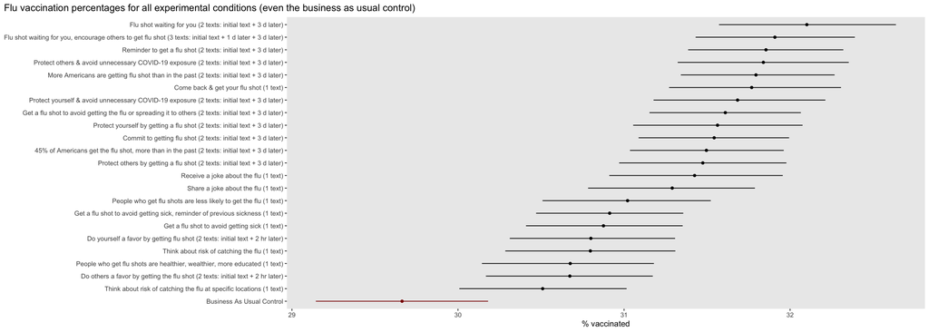

```r
fitted(fit1,
       newdata = nd,
       scale = "linear") %>%
  data.frame() %>%
  mutate_all(inv_logit_scaled) %>%
  bind_cols(nd) %>%
  arrange(nudge) %>%
  mutate(group = factor(condition, ordered = TRUE)) %>%

  ggplot(aes(x = Estimate, xmin = Q2.5, xmax = Q97.5, y = reorder(group, Estimate))) +
  geom_pointrange(aes(color = condition == "Business As Usual Control"),
                  fatten = 1.5) +
  scale_color_manual(values = c("black", "red4"), breaks = NULL) +
  scale_x_continuous("% vaccinated", breaks = 29:32 / 100, labels = 29:32) +
  labs(title = "Flu vaccination percentages for all experimental conditions (even the business as usual control)",
       y = NULL) +
  theme(panel.grid = element_blank(),
        plot.title.position = "plot")
```